# Final Report

# k) Neural Network

```r
library(keras)
set.seed(385)
 keras_train <- ether_df %>%
   sample_frac(.75)
 keras_test <- ether_df %>%
   setdiff(keras_train)
 keras_train_data <- as.matrix(keras_train[!names(ether_df) %in% c("price","log_10_price", "day", "month", "date_utc")])
 keras_test_data <- as.matrix(keras_test[!names(ether_df) %in% c("price","log_10_price", "day", "month", "date_utc")])
 keras_train_labels <- as.matrix(keras_train[, "price"])
 keras_test_labels <- as.matrix(keras_test[, "price"])

 keras_train_data <- scale(keras_train_data)
 keras_test_data <- scale(keras_test_data)




build_model <- function(){
 model <- keras_model_sequential() %>%
    layer_dense(units = 64, activation="relu",
                input_shape = dim(keras_test_data)[2]) %>%
     layer_dense(units = 64, activation = "sigmoid") %>%
     layer_dense(units = 64, activation = "exponential") %>%
     layer_activation_leaky_relu(alpha = 0.01) %>%
     layer_dense(units = 1)

 model %>% compile(
      loss = "mse",
    optimizer = optimizer_rmsprop(),
      metrics = list("mean_absolute_error"))


model
}
model <- build_model()
model %>% summary()
```

```
## ___________________________________________________________________________
## Layer (type)                     Output Shape                  Param #
## ===========================================================================
## dense (Dense)                    (None, 64)                    512
## ___________________________________________________________________________
## dense_1 (Dense)                  (None, 64)                    4160
## ___________________________________________________________________________
## dense_2 (Dense)                  (None, 64)                    4160
## ___________________________________________________________________________
## leaky_re_lu (LeakyReLU)          (None, 64)                    0
## ___________________________________________________________________________
## dense_3 (Dense)                  (None, 1)                     65
## ===========================================================================
## Total params: 8,897
## Trainable params: 8,897
## Non-trainable params: 0
## ___________________________________________________________________________
```

```r
early_stop <- callback_early_stopping(monitor = "val_loss", patience = 68)
epochs <- 325
# set the X and Y

history <- model %>% fit(
  keras_train_data,
  keras_train_labels,
  epochs = epochs,
  validation_split = 0.50
)
```

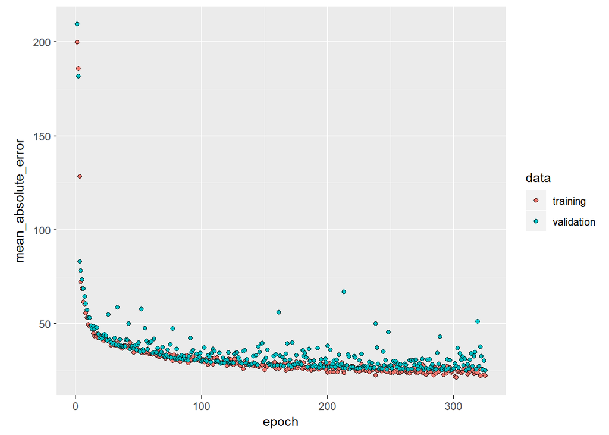

```r
library(ggplot2)
plot(history, metrics = "mean_absolute_error", smooth = FALSE)
```

The mean absolute error stabilizes around 100 epochs or iterations

```r
model_2 <- build_model()

model_2 %>% compile(
  loss="mse",
  optimizer = optimizer_rmsprop(lr = 0.022),
  metrics = list("mean_absolute_error")
)
history2 <- model_2 %>% fit(
  keras_train_data,
  keras_train_labels,
  epochs=100,
  validation_split = 0.50,
  callbacks = list(early_stop)
)
```

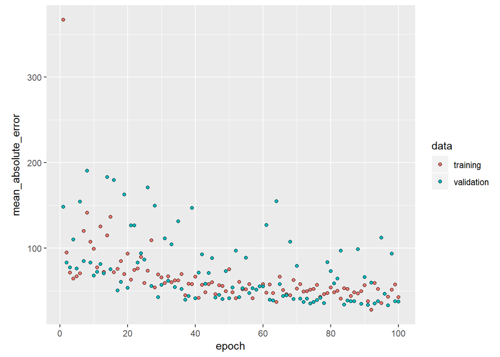

```r
plot(history2, metrics = 'mean_absolute_error', smooth = FALSE)
```

```r
nueral_predictions <- model %>% predict(keras_test_data)
net_mse <- mean((keras_test_labels - nueral_predictions)^2)
net_mse
```

```
## [1] 2806.548
```

A Neural Network performs decently given the complexity of the dataset. I experimented with different activation functions and numbers of layers. Finding success with interweaving layers of relu activation functions as well as exponential activiation functions. This greatly increased the performance of the model though I started having issues where the errors were not converging and took that as a sign that the vanishing gradient problem was taking place. One solution is to include a leaky relu function because it has a negative slope as x decreases it will still register a neuron as firing while a relu won’t. This increased the performance of my model more significantly than adding more layers.

# i.) extra credit

```r
library(caret)

set.seed(20)

train_index <- createDataPartition(ether_df$price, p = .8, list = FALSE, times = 1)

head(train_index)

ether_df_train <- ether_df[train_index, , drop = FALSE]

ether_df_test <- ether_df[-train_index, , drop = FALSE]

tr_control <- trainControl(method = "repeatedcv",
             number = 10,
             repeats = 3
             )
knn_model <-  train(price ~., data = ether_df,
                    method = "knn",
                    preProcess = c("center", "scale"),
                    trControl = tr_control,
                    metric = "RMSE",
                    tuneLength = 10
                    )

knn_model

knn_model$results

y_hat <- predict(knn_model, newdata = ether_df)

predicted <- predict(knn_model, ether_df)

plot(ether_df$price, predicted)
sqrt(sum((predicted - ether_df$price) ^ 2) / length(ether_df))
```

[output not shown]

```r
set.seed(385)

statistic <- function(x, n=100, best=5){
  tree_1 <- tree(price~., data = train_df)
  pruned_tree_1 <- prune.tree(tree_1, k=10, best = best)

 return(  predict(pruned_tree_1, newdata = test_df) )



}

 result <- boot::boot(data = train_df, statistic, R=100, sim = "ordinary")
mean((test_df$price - result$t0)^ 2)
```

```
## [1] 6845.105
```

# m.) comparing all models

```r
single_tree_fit
```

```
## [1] 7065.163
```

```r
lasso_mse
```

```
## [1] 4856.384
```

```r
ridge_mse
```

```
## [1] 6754.554
```

```r
bagging_mse
```

```
## [1] 1023.55
```

```r
mse_random_forest
```

```
## [1] 1033
```

```r
boosting_mse
```

```
## [1] 1299.219
```

```r
mse_tuned
```

```
## [1] 1347.41
```

```r
xg_boosted_mse
```

```
## [1] 1415.984
```

```r
tuned_xgboost_mse
```

```
## [1] 1360.191
```

```r
net_mse
```

```
## [1] 2806.548
```

[output not shown]

# n.) Conclusion

Of all the machine learning techniques covered bagging proved the most accurate model for predicting Ether price. While tree methods generally performed better than other machine learning methods. The techniques covered in class don’t lend themselves naturally to dealing with time series data if we had covered Neural Networks in further depth I believe a neural network could perform better than all the other models. As neural networks lend themselves well with dealing with sequence data and in particular time series data one such technique is LSTM or Long short-term memory. Another possible approach might consider using lags which is out of the scope of the class, but is useful in time series modeling.